# Week44 part two

562770bf

2024-11-4

This is the second Readme file for the Data Science and HR analytics course, trying out experiments on the code for week 45.

So let’s get started.

```r
browser <- read.csv("/Users/annelies2/Downloads/web-browsers.csv")
dim(browser)
```

```
## [1] 10000     7
```

```r
head(browser)
```

```
##   id anychildren broadband hispanic  race region spend
## 1  1           0         1        0 white     MW   424
## 2  2           1         1        0 white     MW  2335
## 3  3           1         1        0 white     MW   279
## 4  4           0         1        0 white     MW   829
## 5  5           0         1        0 white      S   221
## 6  6           0         1        0 white     MW  2305
```

This code reads a CSV file into R, displays its dimensions (number of rows and columns), and shows the first six rows of the data.

```r
mean(browser$spend); var(browser$spend)/1e4; sqrt(var(browser$spend)/1e4)
```

```
## [1] 1946.439
```

```
## [1] 6461.925
```

```
## [1] 80.3861
```

```r
  B <- 1000
  mub <- c()
  for (b in 1:1000){
    samp_b <- sample.int(nrow(browser), replace=TRUE)
    mub <- c(mub, mean(browser$spend[samp_b]))
  }
  sd(mub)
```

```
## [1] 80.46011
```

This code performs a bootstrap resampling procedure 1000 times to estimate the mean of the `spend` variable in the `browser` data frame and then calculates the standard deviation of the resampled means.

```r
# Experiment 1: Varying the number of bootstrap samples (B)
B_values <- c(500, 1000, 5000)  # Different values for B
for (B in B_values) {
  mub <- c()
  for (b in 1:B) {
    samp_b <- sample.int(nrow(browser), replace=TRUE)
    mub <- c(mub, mean(browser$spend[samp_b]))
  }
  cat("B =", B, "SD of bootstrap means:", sd(mub), "\n")
}
```

```
## B = 500 SD of bootstrap means: 78.85099
## B = 1000 SD of bootstrap means: 78.91449
## B = 5000 SD of bootstrap means: 79.22369
```

```r
# Experiment 2: Using sample() instead of sample.int() for resampling
B <- 1000
mub <- c()
for (b in 1:B) {
  samp_b <- sample(1:nrow(browser), size=nrow(browser), replace=TRUE)  # Random resampling
  mub <- c(mub, mean(browser$spend[samp_b]))
}
cat("SD of bootstrap means with sample() method:", sd(mub), "\n")
```

```
## SD of bootstrap means with sample() method: 84.93452
```

```r
# Experiment 3: Calculate a 95% confidence interval from bootstrap means
B <- 1000
mub <- c()
for (b in 1:B) {
  samp_b <- sample.int(nrow(browser), replace=TRUE)
  mub <- c(mub, mean(browser$spend[samp_b]))
}

# Confidence interval
CI <- quantile(mub, c(0.025, 0.975))  # 95% confidence interval
cat("95% Confidence Interval:", CI, "\n")
```

```
## 95% Confidence Interval: 1791.524 2109.597
```

```r
# Experiment 4: Compare bootstrap means to actual mean
actual_mean <- mean(browser$spend)  # Actual mean of the 'spend' variable
cat("Actual mean:", actual_mean, "\n")
```

```
## Actual mean: 1946.439
```

```r
B <- 1000
mub <- c()
for (b in 1:B) {
  samp_b <- sample.int(nrow(browser), replace=TRUE)
  mub <- c(mub, mean(browser$spend[samp_b]))
}

# Compare bootstrap mean to actual mean
bootstrap_mean <- mean(mub)
cat("Bootstrap mean:", bootstrap_mean, "\n")
```

```
## Bootstrap mean: 1946.351
```

From the experiments, I learned that:

Bootstrap confidence intervals provide a range of plausible values for the population mean, offering valuable insights into the uncertainty around the estimate. A 95% confidence interval based on bootstrap resampling captures the variability in the data and can help assess the precision of the mean estimate.

The bootstrap mean was very close to the actual population mean of the `spend` variable, demonstrating that the bootstrap method is effective in approximating population parameters even with limited data.

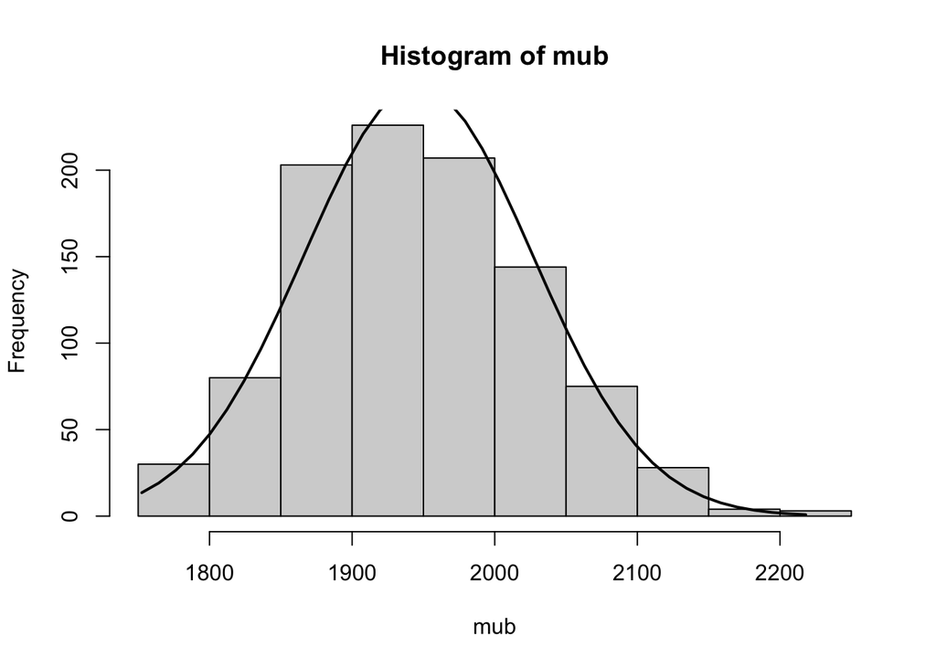

```r
  h <- hist(mub)
  xfit <- seq(min(mub), max(mub), length = 40)
  yfit <- dnorm(xfit, mean = mean(browser$spend), sd = sqrt(var(browser$spend)/1e4))
  yfit <- yfit * diff(h$mids[1:2]) * length(mub)
  lines(xfit, yfit, col = "black", lwd = 2)
```

First line creates a histogram of the bootstrap sample means (mub) and stores it in the object h. This helps visualize the distribution of the bootstrap means. Xfit generates a sequence of 40 evenly spaced points (xfit) between the minimum and maximum values of the mub vector. These points will be used to evaluate the fitted normal distribution. Yfit calculates the probability density values of the normal distribution (dnorm) at each point in xfit, assuming a normal distribution with the mean and adjusted standard deviation based on the original. Fourth line scales the normal density to match the histogram’s area: diff(h$mids[1:2]): The width of a histogram bin, ensuring the density matches the width of the bars in the histogram. length(mub): Adjusts the density for the total number of bootstrap samples to scale the normal curve appropriately to match the histogram's total count.browser$spend data. Fifth line adds the fitted normal curve to the histogram, using the calculated points (xfit, yfit) and styling it as a black line with a width of 2.

```r
B <- 1000
  betas <- c()
  for (b in 1:1000){
    samp_b <- sample.int(nrow(browser), replace=TRUE)
    reg_b <- glm(log(spend) ~ broadband + anychildren, data=browser[samp_b,])
    betas <- rbind(betas, coef(reg_b))
  }; head(betas, n=3)
```

```
##      (Intercept) broadband anychildren
## [1,]    5.673266 0.5523496  0.08278722
## [2,]    5.726175 0.5193417  0.09127457
## [3,]    5.697066 0.5436738  0.10795902
```

```r
  cov(betas[,"broadband"], betas[,"anychildren"])
```

```
## [1] -8.35578e-05
```

```r
B <- 2000  # Increase the number of bootstrap samples
betas <- c()
for (b in 1:B) {
  samp_b <- sample.int(nrow(browser), replace=TRUE)
  reg_b <- glm(log(spend) ~ broadband + anychildren, data=browser[samp_b,])
  betas <- rbind(betas, coef(reg_b))
}
cov(betas[,"broadband"], betas[,"anychildren"])
```

```
## [1] -3.99862e-05
```